# Final Project

Yu Zhang

2022-12-16

# Introduction

## Introduce the dataset and question

Occasional anxiety, as a component of human emotions, is a usual part of life. People worry about different problems. But anxiety disorder involves more than temporary worry or fear. It is a cluster of mental disorders characterized by significant and uncontrollable feelings of anxiety and fear such that a person’s social, occupational, and personal function are significantly impaired.  
In recent years many published studies investigated potential effects of playing video games toward anxiety disorder. Most of them argued that playing video games provides significant benefits for mitigating anxiety disorder. Considering that some of these studies might be funded by the flourishing gaming industry, I doubt about the relationship between playing video games and anxiety disorder founded by existing studies. Hence, my question is that will playing video games with high intensity will increase the risk of having anxiety disorder? I will use the “Online Gaming Anxiety Data” dataset to investigate my question.  
The “Online Gaming Anxiety Data” that I use is a dataset consists of data collected as a part of a survey among gamers worldwide. The dataset consists of 55 columns of variables and 13464 rows of observations which provide information of each observation about his/her gaming-life pattern, responses to psychology questions, and personal information. It can be found on https://www.kaggle.com/datasets/divyansh22/online-gaming-anxiety-data.

## Exploratory data analysis

In this dataset, I mainly focus on two variables. The first is the Generalized Anxiety Disorder (GAD) score, which is an indicator of the risk of having anxiety disorder. The second is the gaming hours per week, which is an indicator of the gaming intensity. For the GAD score, I add up the scores of all seven questions for each subject and yield a variable called “GAD_T”, which ranges from 0 to 21. The “GAD_T” could be used as an indicator of anxiety level and a higher “GAD_T” score indicate more anxiety.  
For exploratory data analysis, I clean the data by removing subjects with NA values. I also remove 31 subjects with gaming hours more than 100 hours per week because game more than 100 hours per week seems unrealistic. I plot the distribution of the gaming hours per week and total “GAD_T” score. From the graphs, both distributions are right skewed. The distribution of weekly gaming hours is centered from 10 to 25 hours per week. And most subjects reported a relatively low anxiety score.

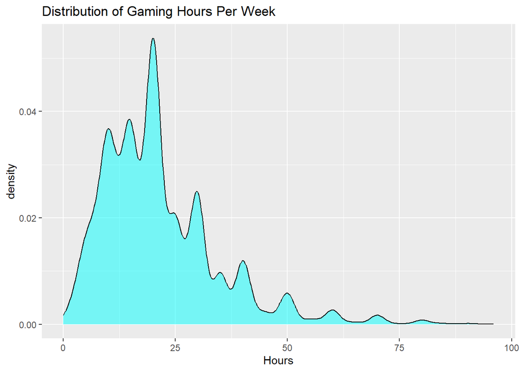

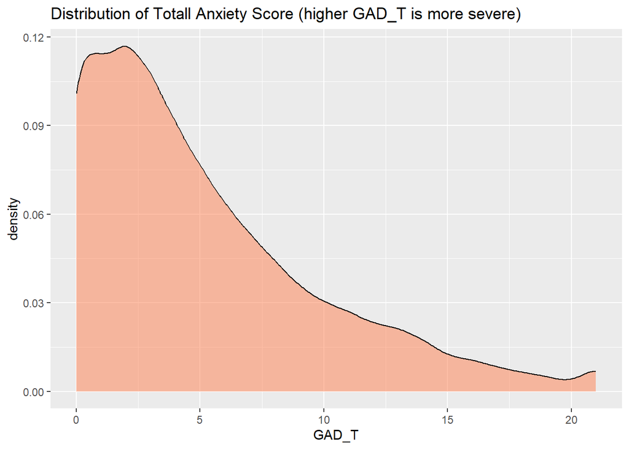

## Method

In this project, I will perform linear regression model analyses and association test analyses to investigate my problem. For linear regression analyses, I will try to model the anxiety scores in terms of weekly gaming hours. If a robust linear regression is found, the slope of the model will answer my question. If high gaming intensity increase the risk of having anxiety disorder, the slope will be positive and vice versa. For association test analyses, I will put anxiety scores and weekly gaming hours into categories. By constructing two-way tables for both observe values and expected values, I can perform a Pearson’s chi square test of independence to see if there is an association between gaming intensity and the risk of having anxiety disorder.

# Result

First of all, I use simple linear regression to model anxiety scores in terms of weekly gaming hours trying to find if they are linearly associated with each other. I also plot the fitted line on the scatter plot of GAD_T vs. Hours. But since both weekly gaming hours and anxiety scores are discrete variables, using regular scatter plot would lead to a problem that many data points cover each other. Hence, I use “geom_jitter” function to create random fluctuation on each data point for better visualization (Plot 1).

```
##
## Call:
## lm(formula = GAD_T ~ Hours, data = dfc)
##
## Residuals:
##    Min     1Q Median     3Q    Max
## -7.495 -3.491 -1.152  2.317 16.451
##
## Coefficients:
##             Estimate Std. Error t value Pr(>|t|)
## (Intercept) 4.482324   0.077355   57.95   <2e-16 ***
## Hours       0.033474   0.003077   10.88   <2e-16 ***
## ---
## Signif. codes:  0 '***' 0.001 '**' 0.01 '*' 0.05 '.' 0.1 ' ' 1
##
## Residual standard error: 4.68 on 13401 degrees of freedom
## Multiple R-squared:  0.008752,   Adjusted R-squared:  0.008678
## F-statistic: 118.3 on 1 and 13401 DF,  p-value: < 2.2e-16
```

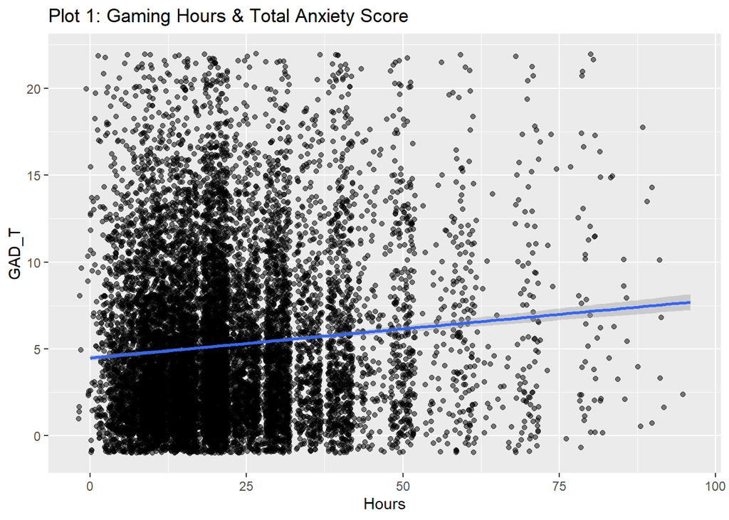

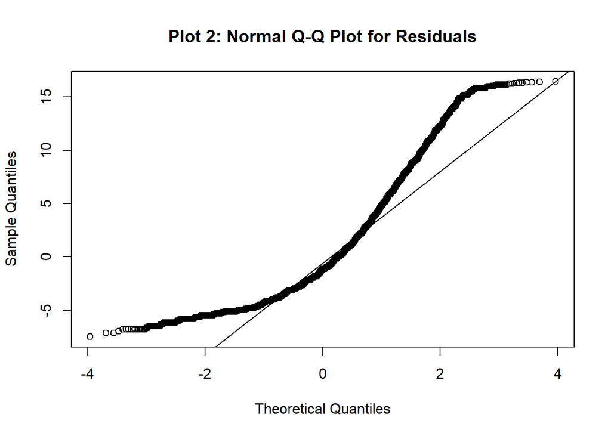

```
##
## Call:
## lm(formula = sqrtGAD ~ sqrtHours, data = df2)
##
## Residuals:
##     Min      1Q  Median      3Q     Max
## -2.2892 -0.6323  0.0143  0.7706  2.7819
##
## Coefficients:
##             Estimate Std. Error t value Pr(>|t|)
## (Intercept) 1.715045   0.033220  51.627   <2e-16 ***
## sqrtHours   0.060521   0.007176   8.434   <2e-16 ***
## ---
## Signif. codes:  0 '***' 0.001 '**' 0.01 '*' 0.05 '.' 0.1 ' ' 1
##
## Residual standard error: 1.123 on 13401 degrees of freedom
## Multiple R-squared:  0.00528,    Adjusted R-squared:  0.005206
## F-statistic: 71.13 on 1 and 13401 DF,  p-value: < 2.2e-16
```

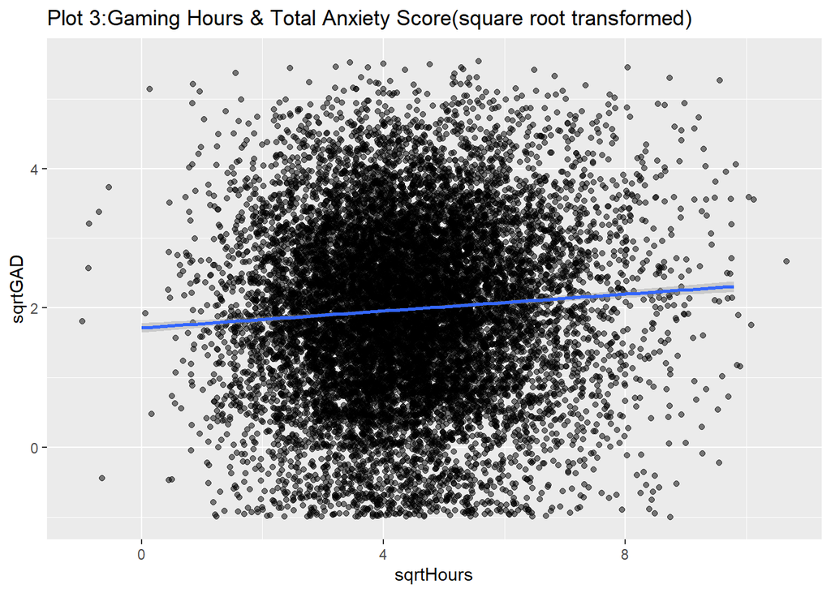

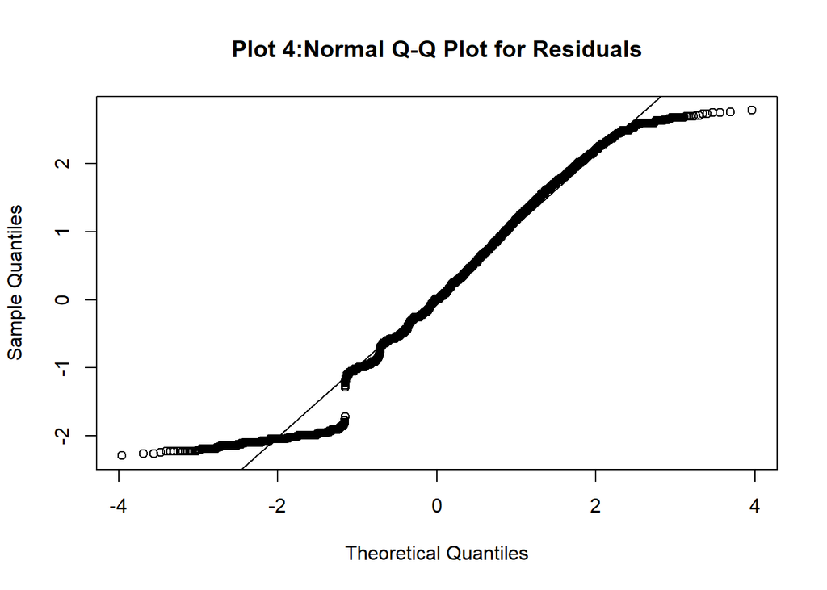

My question about the relationship between gaming intensity and the risk of having anxiety disorder can also be analysed with Association tests. Having a non-zero total GAD score does not imply anxiety disorder since most people tend to worry about something. According to the guidance of GAD-7 Questionnaire, a total score of 15 or higher indicates a high risk of having anxiety disorder. Hence I put all GAD score into to categories: less than 15 and more than or equal to 15, which are corresponding to low risk of anxiety disorder and high risk of anxiety disorder. I also put weekly gaming hours into three categories: less than 10 hours per week, 10 hours to 21 hours per week, and more than 21 hours per week, which corresponding to leisure gaming, moderate gaming, and excessive gaming. The result two-way table is shown below.

| Anxiety Risk/Gaming Intensity | Leisure Gaming | Moderate Gaming | Excessive Gaming |
| --- | --- | --- | --- |
| High Risk | 78 | 335 | 315 |
| Low Risk | 1568 | 6781 | 4326 |

Then I will construct a Pearson’s chi square test for testing the association between risk of anxiety disorder and gaming intensity. The null hypothesis is that the risk of anxiety disorder is independent from gaming intensity. And the alternative hypothesis is that the risk of anxiety disorder is not independent from gaming intensity. Under the null, the probability to have a high risk of anxiety disorder will be same across all three gaming intensities. Hence, I construct a table of expected value under the null, which is shown below.

| Anxiety Risk/Gaming Intensity | Leisure Gaming | Moderate Gaming | Excessive Gaming |
| --- | --- | --- | --- |
| High Risk | 89 | 386 | 252 |
| Low Risk | 1556 | 6729 | 4388 |

After geting these observed values table and expected values table, the chi-squared statistic can be calculated through
$$\chi^2= \Sigma_{i=1}^n
(O_i-E_i)^2/E_i$$
with degrees of freedom equals 2, which is gotten from the number of rows minus one times the number of columns minus one. The result is shown on the table below.

| Chi_sqared | df | p.value |
| --- | --- | --- |
| 25.40457 | 2 | 3e-06 |

From the result of Pearson’s Chi square test, I reject the null with p-value less than 0.05, and conclude that there is enough evidence showing that the risk of having anxiety disorder is not independent from the gaming intensity. Also, by observing the observed values table and expected values table, it can be found that, excessive gaming does increase the risk of having anxiety disorder.

# Conclusion

My question of this project is that will playing video games with high intensity will increase the risk of having anxiety disorder? From all my analysis, the answer is yes, high intensity of gaming will increase the risk of having anxiety. The linear regression analyses give me positive slope for weekly gaming hours, which indicates a positive relationship between intensity of gaming and the risk of having anxiety. Although the value of the slope is relatively low, it is statistically significant with very a small p-value. The association test through Pearson’s chi square test, provide a better view of the data by transform variables into a few crucial categories. The result of the test shows that the risk of having anxiety is not independent of intensity of gaming, and excessive gaming does increase the risk of having anxiety.  
My analysis are relatively successful because the key statistics are both statistically significant, and both analysis show similar result. However, my analysis are not perfect because I did not considering the effect of other variables. Other variables such as employment status, age, gender, could significantly effect the relationship between gaming intensity and anxiety risk. There could also be potential confoundings or effect modifications. If I had more time, I would investigate my question by considering more variables.

# References

Data: https://www.kaggle.com/datasets/divyansh22/online-gaming-anxiety-data

Barnes, Steven, and Julie Prescott. “Empirical evidence for the outcomes of therapeutic video games for adolescents with anxiety disorders: systematic review.” JMIR serious games 6.1 (2018): e9530.

Craske, Michelle G., et al. “What is an anxiety disorder?.” Focus 9.3 (2011): 369-388.

Diagnostic and statistical manual of mental disorders 5th edition: DSM-5. Arlington, VA Washington, D.C: American Psychiatric Association,American Psychiatric Association. 2013. p. 189–195. ISBN 978-0-89042-555-8. OCLC 830807378.

Davison GC (2008). Abnormal Psychology. Toronto: Veronica Visentin. p. 154. ISBN 978-0-470-84072-6.

Kowal, Magdalena, et al. “Gaming your mental health: a narrative review on mitigating symptoms of depression and anxiety using commercial video games.” JMIR Serious Games 9.2 (2021): e26575.

# Appendix

```r
knitr::opts_chunk$set(echo = TRUE)
library(tidyverse)
df <- read_csv("GamingStudy_data.csv")
```

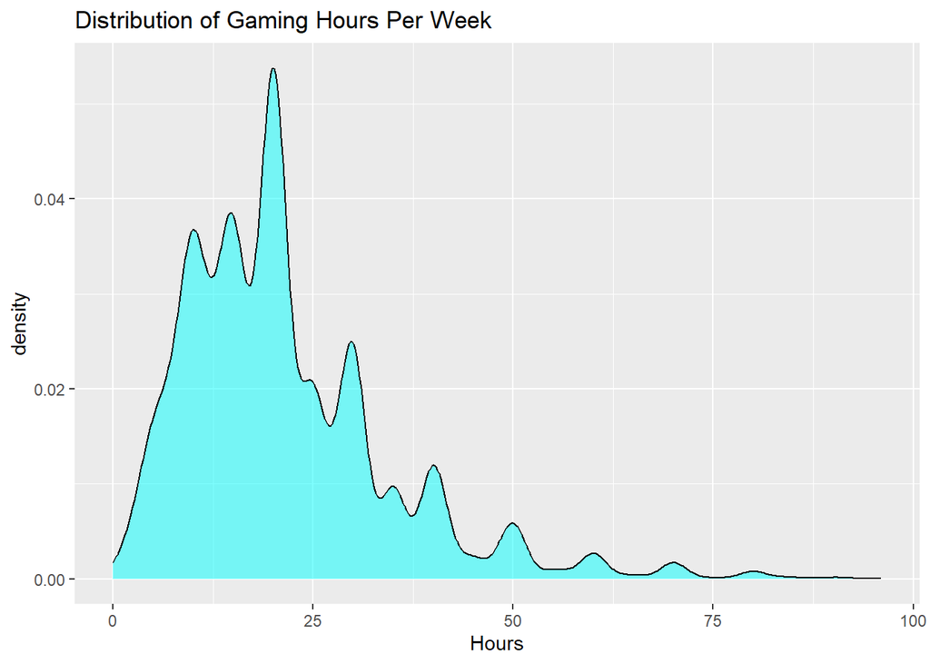

```r
dfc <- df %>% drop_na(Hours) %>% filter(Hours < 100 )
ggplot(dfc)+
    geom_density(mapping=aes(x=Hours),fill ='cyan',alpha = .5)+
    labs(title='Distribution of Gaming Hours Per Week')
```

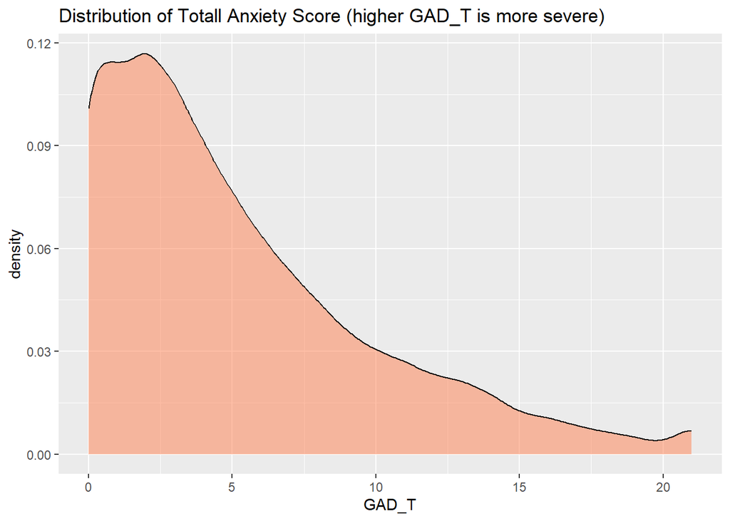

```r
ggplot(dfc)+
    geom_density(mapping=aes(x=GAD_T),fill ='coral',alpha = .5)+
    labs(title='Distribution of Totall Anxiety Score (higher GAD_T is more severe)')
```

```r
mod1 <- lm(GAD_T ~ Hours, data = dfc)
summary(mod1)
```

```
##
## Call:
## lm(formula = GAD_T ~ Hours, data = dfc)
##
## Residuals:
##    Min     1Q Median     3Q    Max
## -7.495 -3.491 -1.152  2.317 16.451
##
## Coefficients:
##             Estimate Std. Error t value Pr(>|t|)
## (Intercept) 4.482324   0.077355   57.95   <2e-16 ***
## Hours       0.033474   0.003077   10.88   <2e-16 ***
## ---
## Signif. codes:  0 '***' 0.001 '**' 0.01 '*' 0.05 '.' 0.1 ' ' 1
##
## Residual standard error: 4.68 on 13401 degrees of freedom
## Multiple R-squared:  0.008752,   Adjusted R-squared:  0.008678
## F-statistic: 118.3 on 1 and 13401 DF,  p-value: < 2.2e-16
```

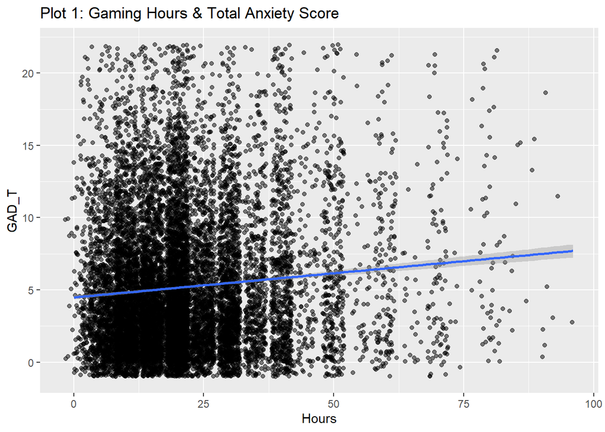

```r
dfc %>% ggplot(aes(Hours, GAD_T)) +
  geom_jitter(width = 2, height = 1, alpha = 0.5) +
  geom_smooth(method = "lm") +
  labs(title='Plot 1: Gaming Hours & Total Anxiety Score')
```

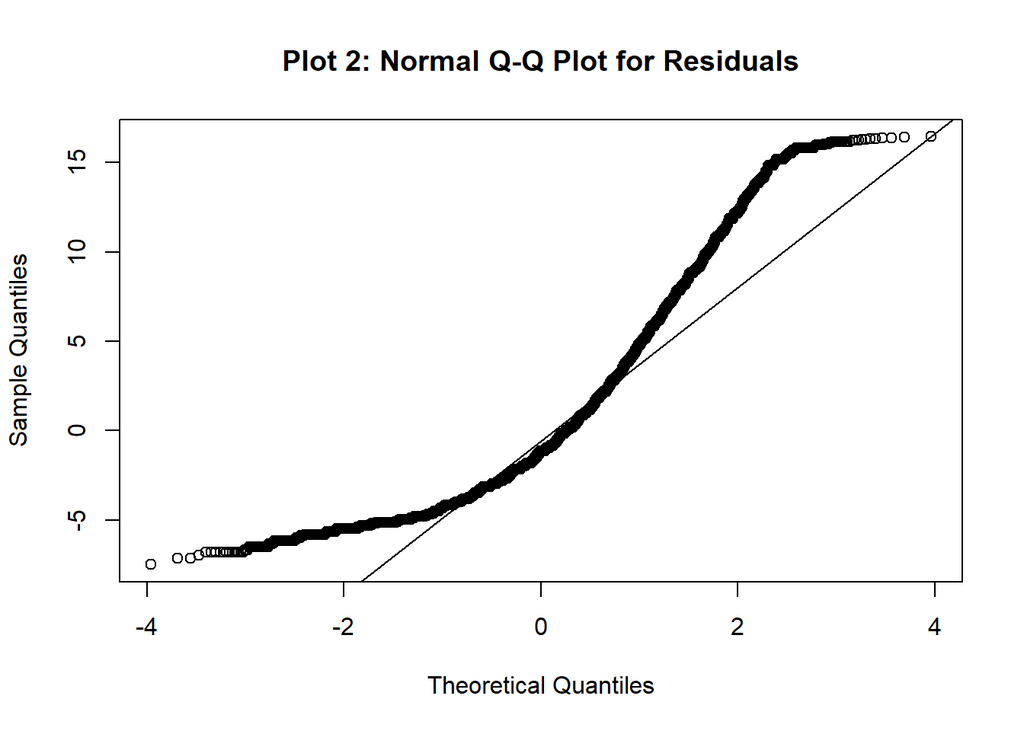

```r
qqnorm(resid(mod1), main = "Plot 2: Normal Q-Q Plot for Residuals")
qqline(resid(mod1))
```

```r
df2 <- dfc %>% mutate(sqrtHours = sqrt(Hours)) %>%
  mutate(sqrtGAD = sqrt(GAD_T))
mod2 <- lm(sqrtGAD ~ sqrtHours, data = df2)
summary(mod2)
```

```
##
## Call:
## lm(formula = sqrtGAD ~ sqrtHours, data = df2)
##
## Residuals:
##     Min      1Q  Median      3Q     Max
## -2.2892 -0.6323  0.0143  0.7706  2.7819
##
## Coefficients:
##             Estimate Std. Error t value Pr(>|t|)
## (Intercept) 1.715045   0.033220  51.627   <2e-16 ***
## sqrtHours   0.060521   0.007176   8.434   <2e-16 ***
## ---
## Signif. codes:  0 '***' 0.001 '**' 0.01 '*' 0.05 '.' 0.1 ' ' 1
##
## Residual standard error: 1.123 on 13401 degrees of freedom
## Multiple R-squared:  0.00528,    Adjusted R-squared:  0.005206
## F-statistic: 71.13 on 1 and 13401 DF,  p-value: < 2.2e-16
```

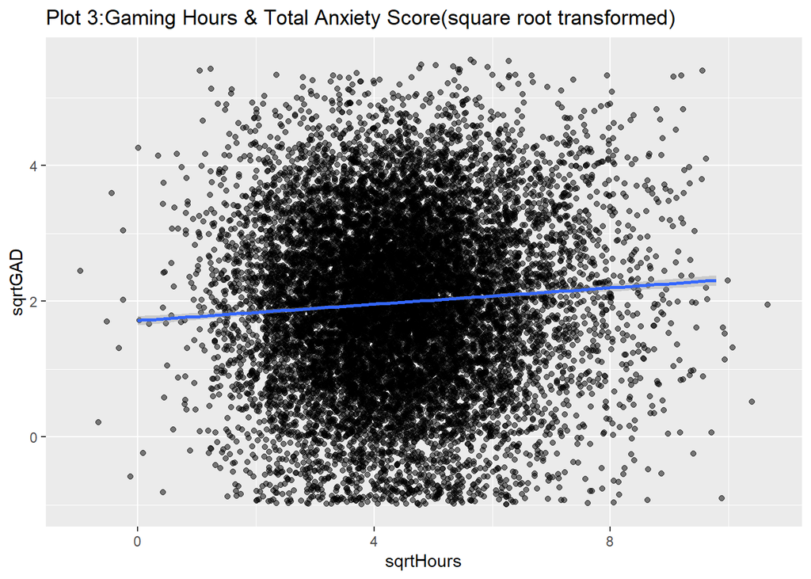

```r
df2 %>% ggplot(aes(sqrtHours, sqrtGAD)) +
  geom_jitter(width = 1, height = 1, alpha = 0.5) +
  geom_smooth(method = "lm") +
  labs(title='Plot 3:Gaming Hours & Total Anxiety Score(square root transformed)')
```

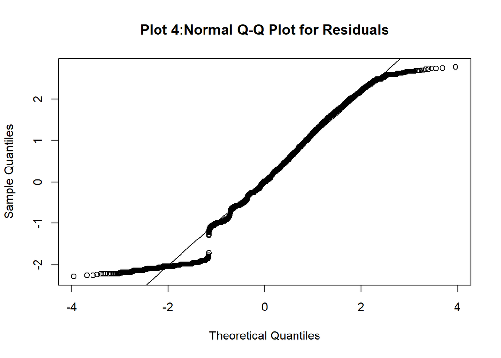

```r
qqnorm(resid(mod2), main = "Plot 4:Normal Q-Q Plot for Residuals")
qqline(resid(mod2))
```

```r
dfa <- dfc %>% mutate(GADcat = case_when(GAD_T < 15 ~ "Low Risk",
                                         GAD_T >= 15 ~ "High Risk")) %>%
  mutate(Hourscat = case_when(Hours < 10 ~ "Leisure Gaming",
                              Hours >= 10&Hours <= 21 ~ "Moderate Gaming",
                              Hours > 21 ~ "Excessive Gaming"))
count_a <- dfa %>% group_by(GADcat) %>% count(Hourscat)
count_w <- spread(count_a, key = Hourscat, value = n)
count_w <- count_w[,c("GADcat","Leisure Gaming", "Moderate Gaming", "Excessive Gaming")]
colnames(count_w)[1] <- "Anxiety Risk/Gaming Intensity"
knitr::kable(count_w)
```

| Anxiety Risk/Gaming Intensity | Leisure Gaming | Moderate Gaming | Excessive Gaming |
| --- | --- | --- | --- |
| High Risk | 78 | 335 | 315 |
| Low Risk | 1568 | 6781 | 4326 |

```r
count_e <- count_w
hrsum <- sum(count_w[1,2:4])
lrsum <- sum(count_w[2,2:4])
lgsum <- sum(count_w[,2])
mgsum <- sum(count_w[,3])
egsum <- sum(count_w[,4])
expratio <- hrsum/(hrsum+lrsum)
count_e[1,2] <- as.integer(lgsum*expratio)
count_e[2,2] <- as.integer(lgsum-lgsum*expratio)
count_e[1,3] <- as.integer(mgsum*expratio)
count_e[2,3] <- as.integer(mgsum-mgsum*expratio)
count_e[1,4] <- as.integer(egsum*expratio)
count_e[2,4] <- as.integer(egsum-egsum*expratio)
knitr::kable(count_e)
```

| Anxiety Risk/Gaming Intensity | Leisure Gaming | Moderate Gaming | Excessive Gaming |
| --- | --- | --- | --- |
| High Risk | 89 | 386 | 252 |
| Low Risk | 1556 | 6729 | 4388 |

```r
chi_square_test <- count_w %>% as.data.frame() %>%  select(-"Anxiety Risk/Gaming Intensity") %>%  chisq.test()
a <- chi_square_test$statistic
b <- chi_square_test$parameter
c <- chi_square_test$p.value
d <- data.frame("Chi_sqared" = a, "df" = b, "p-value" = c)
d <- remove_rownames(d)
knitr::kable(d)
```

| Chi_sqared | df | p.value |
| --- | --- | --- |
| 25.40457 | 2 | 3e-06 |